# Data Analysis

# Finding #7

Plot of range of balance for each job  
**Insight:** *retired people have the highest average bank balance*

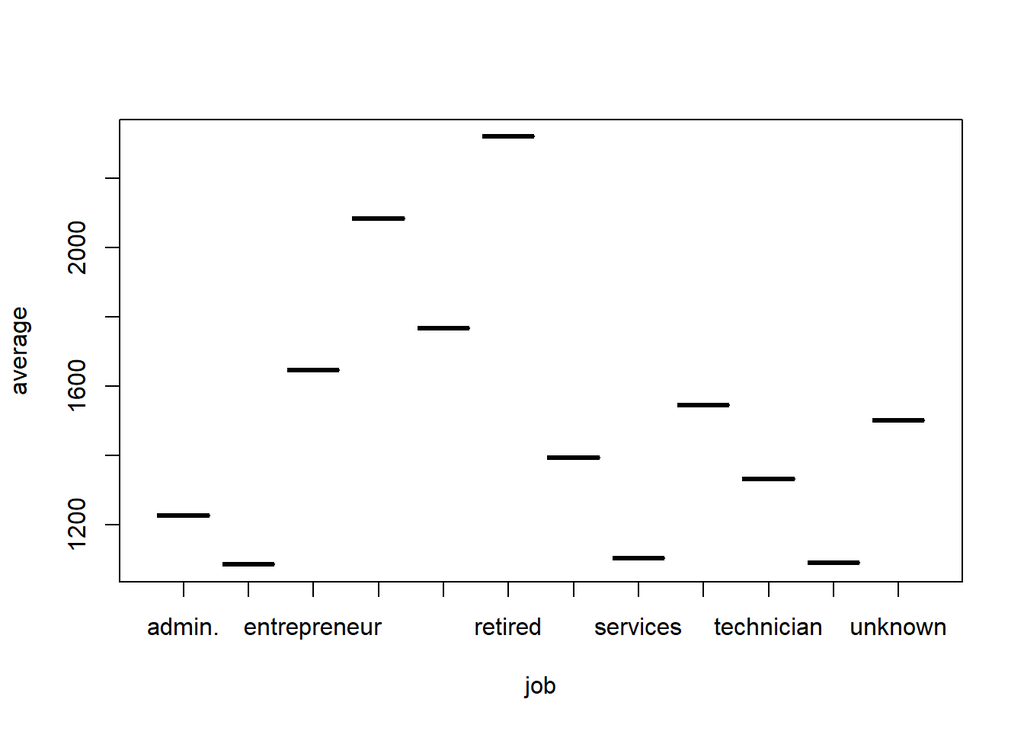

```r
bank %>%
  group_by(job) %>%
  summarise(average=mean(balance))-> result
plot(result)
```

# Finding #8  
Plot of range of age for each job  
**Insight:** *retired people can be as young as 20s*

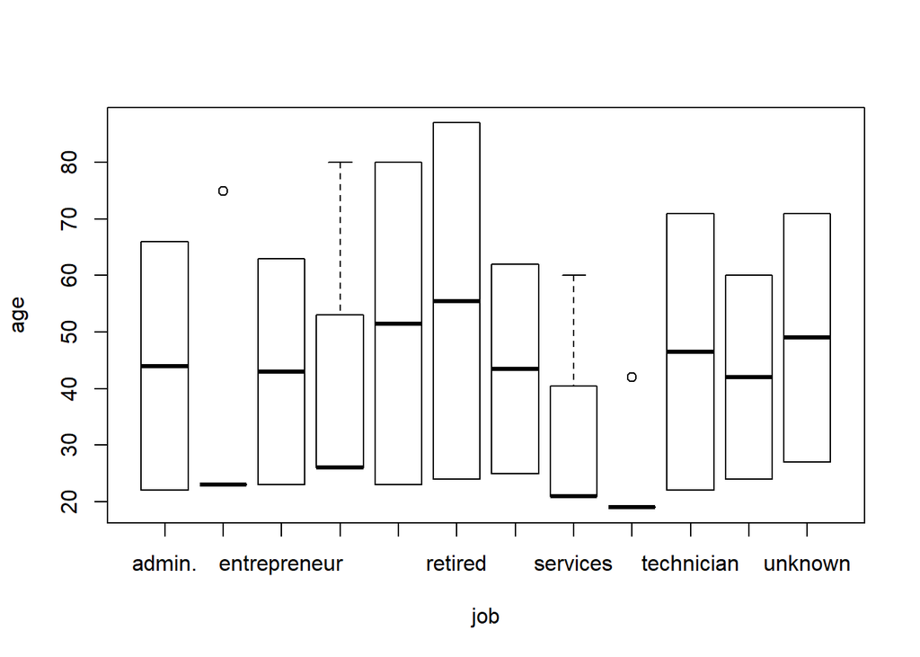

```r
bank %>%
  group_by(job) %>%
  filter(min_rank(age) == 1 | min_rank(desc(age)) == 1) %>%
  select(job,age) -> result
plot(result)
```

# Finding #9  
Plot of bank balnace for each individual with no loans by job  
**Insight:** *profile of new potential customers*

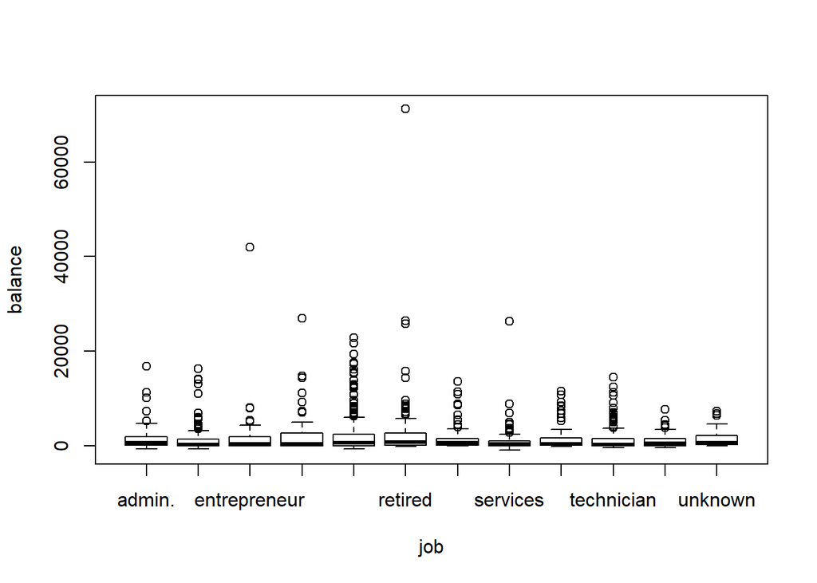

```r
bank %>%
  filter(loan == "no" & housing == "no")%>%
  group_by(job)%>%
  select(job,balance)%>%
  plot()
```

# Finding #10  
Boxplot of duration of contact (in mins) given client has subscribed a term deposit  
**Insight:** *it takes on average 9mins to secure a client, with successful phone call as short as 30sec*

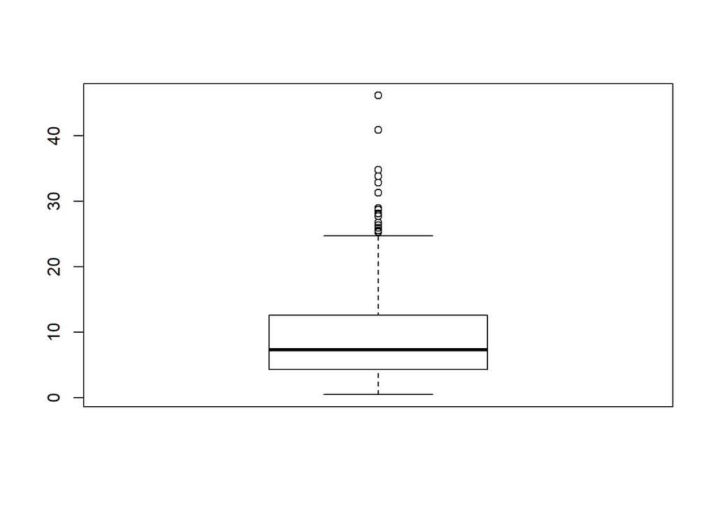

```r
bank %>%
  filter(y == "yes")%>%
  select(duration)/60 -> result
boxplot(result)
```

```r
summary(result)
```

```
##     duration
##  Min.   : 0.500
##  1st Qu.: 4.333
##  Median : 7.367
##  Mean   : 9.212
##  3rd Qu.:12.583
##  Max.   :46.150
```